# Final Project

Abha Namjoshi

2025-12-05

# Introduction

This report uses the *Heart Failure Prediction* dataset from Kaggle, which contains 918 adults and 12 routinely collected clinical variables. It has a binary outcome of aquiring HeartDisease where 1 = disease, 0 = no disease. Predictors include demographics such as age and sex, variables about symptoms and EKG changes that include ChestPainType, RestingECG, ExerciseAngina, ST_Slope, vitals and labs (RestingBP, Cholesterol, FastingBS), and exercise test metrics (MaxHR, Oldpeak). Some inconsistencies such as zeros in variable Cholesterol are observed which will be examined during preprocessing.  
Dataset link: https://www.kaggle.com/datasets/fedesoriano/heart-failure-prediction

## Objectives

1. Describe the data with summary statistics and visualizations of key risk factors.
2. Explore relationships between each predictor variable and the heart-disease outcome.
3. Fit and interpret a logistic regression model to quantify associations and predict heart disease outcome

# Tabular analysis

| **Characteristic** | **Overall** N = 918<sup>1</sup> | **Heart Disease Status** **0** N = 410<sup>1</sup> | **Heart Disease Status** **1** N = 508<sup>1</sup> | **p-value**<sup>2</sup> |  |
| --- | --- | --- | --- | --- | --- |
| Sex |  |  |  |  | <0.001 |
| F | 193 (21%) | 143 (35%) | 50 (9.8%) |  |  |
| M | 725 (79%) | 267 (65%) | 458 (90%) |  |  |
| Age (years) | 54 (47, 60) | 51 (43, 57) | 57 (51, 62) | <0.001 |  |
| Chest pain type |  |  |  | <0.001 |  |
| ASY | 496 (54%) | 104 (25%) | 392 (77%) |  |  |
| ATA | 173 (19%) | 149 (36%) | 24 (4.7%) |  |  |
| NAP | 203 (22%) | 131 (32%) | 72 (14%) |  |  |
| TA | 46 (5.0%) | 26 (6.3%) | 20 (3.9%) |  |  |
| Resting BP (mmHg) | 130 (120, 140) | 130 (120, 140) | 132 (120, 145) | <0.001 |  |
| Cholesterol (mg/dL) | 223 (173, 267) | 227 (197, 267) | 217 (0, 267) | <0.001 |  |
| Max heart rate (bpm) | 138 (120, 156) | 150 (134, 165) | 126 (112, 145) | <0.001 |  |
| Exercise-induced angina |  |  |  | <0.001 |  |
| N | 547 (60%) | 355 (87%) | 192 (38%) |  |  |
| Y | 371 (40%) | 55 (13%) | 316 (62%) |  |  |
| ST slope at peak exercise |  |  |  | <0.001 |  |
| Down | 63 (6.9%) | 14 (3.4%) | 49 (9.6%) |  |  |
| Flat | 460 (50%) | 79 (19%) | 381 (75%) |  |  |
| Up | 395 (43%) | 317 (77%) | 78 (15%) |  |  |

<sup>1</sup> n (%); Median (Q1, Q3)  
<sup>2</sup> Pearson’s Chi-squared test; Wilcoxon rank sum test

# Graphical Analysis

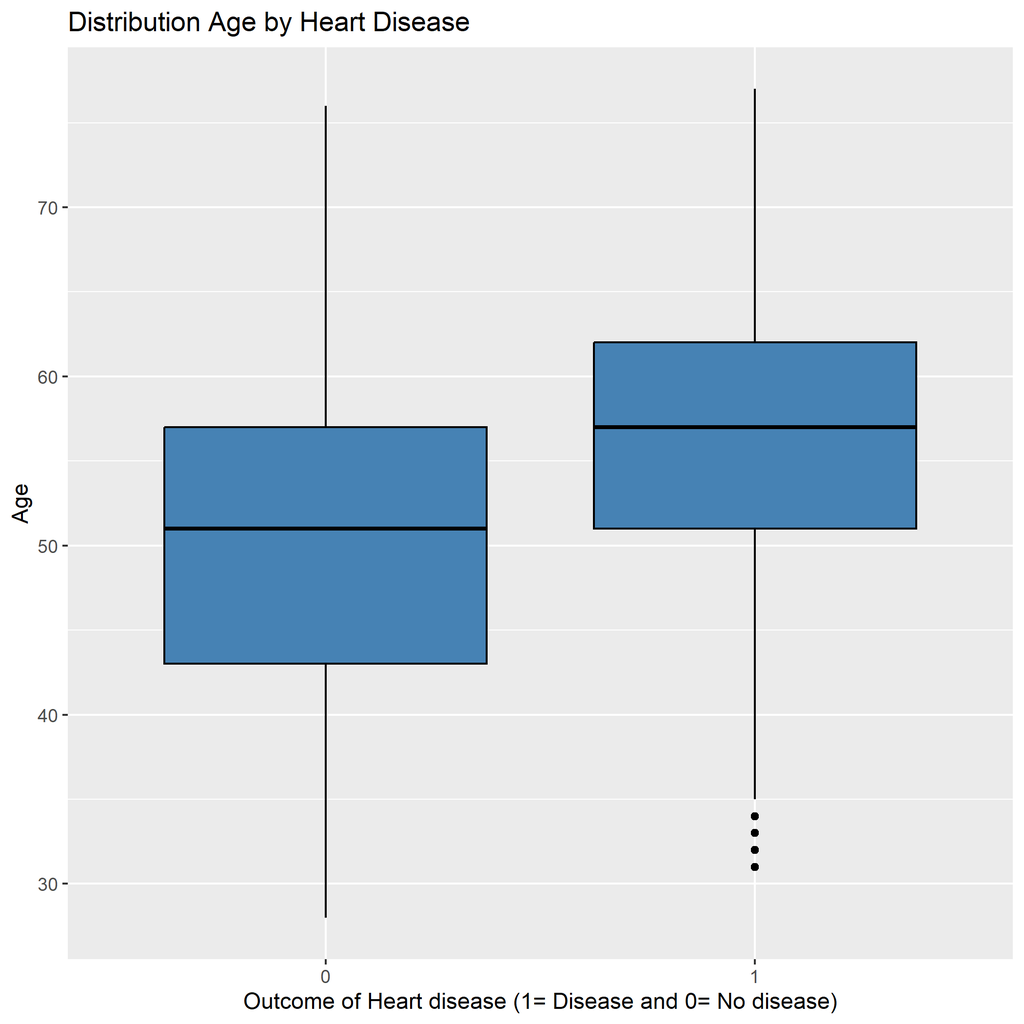

## Description

The box plot gives us distribution of age with the presence or absence of disease outcome. We can observe that Median age with those with the disease is higher than those without the disease outcome. This is indicative of association of disease with increase in age.